# Machine Learning II Project Report

## 5.3 Accumulated Local Effects (ALE)

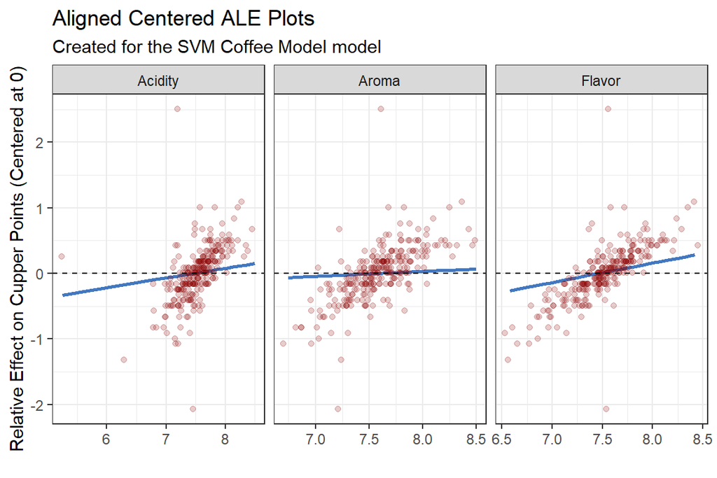

## 5.4 Shapley Additive Explanations (SHAP)

The SHAP is a Local Explanation, which acts like a “scorecard” for one specific cup of coffee to show why it received its particular prediction.

**FOR SVM SHAP;** In this specific example *(the number of observation is 100)*, the model’s prediction was dragged down primarily because the Balance, Flavor, and Aftertaste scores were lower than average, as shown by the red bars extending to the left. On the other hand, the green bars show that this coffee’s Aroma and Clean Cup scores actually helped boost its final rating. Essentially, this plot shows exactly which characteristics made this specific cup of coffee better or worse than a typical sample.

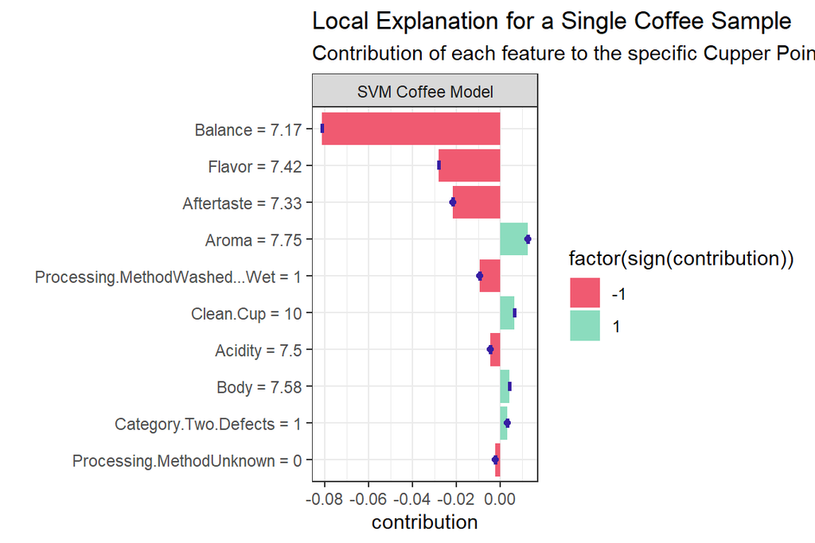

# 6 Literature

Chen, Tianqi. 2016. “XGBoost: A Scalable Tree Boosting System.” *Cornell University*.

Friedman, Jerome H. 2001. “Greedy Function Approximation: A Gradient Boosting Machine.” *Annals of Statistics*, 1189–1232.

James, Gareth, Daniela Witten, Trevor Hastie, and Robert Tibshirani. 2021. *An Introduction to Statistical Learning: With Applications in r*. 2nd ed. Springer. https://doi.org/10.1007/978-1-0716-1418-1.